# Auckland Bike data analysis

Ghassan Al-A’raj

#Load data

```r
#bike data
bike_files<- list.files("data/BIKES",pattern = ".csv" ,full=TRUE)
bike_data<-map(bike_files,read_csv)
bike_tidy<-map(bike_data, pivot_longer, values_to ="rider_count", names_to ="counter", -Date)
allbikes<-bind_rows(bike_tidy)
```

```r
#rain data
rain_files<- list.files("data/RAIN",pattern = ".txt" ,full=TRUE)
rain_data<-map(rain_files,read_csv)
allrain <- bind_rows(rain_data)
```

Compute the total number of cyclists counted for each day, and a suitable summary of the rainfall for each day, in the same data frame.

#clean the bike data set

```r
#make sure names are consistent and remove NAs in the data set.
allbikes <- allbikes[!is.na(allbikes$Date) & !is.na(allbikes$counter) & !is.na(allbikes$rider_count),]
name_table <- read_csv("bikes_done.csv",col_names = TRUE)
allbikes <- join(allbikes, name_table, by = NULL, type = "left", match = "all")
```

#fix date column

```r
time.data <- t(sapply(allbikes$Date, function(x) substring(x, first=c(1,5,7,11), last=c(4,6,10,15))))
time.df <- data.frame(wday = time.data[,1],
                      day = time.data[,2],
                      month = time.data[,3],
                      year = time.data[,4])

time.df$month = trimws(time.df$month)

dates <- paste(time.df$year,time.df$month,time.df$day,sep="-")

time.df$date <- strptime(dates , format="%Y-%b-%d", tz = "GMT")
allbikes$Date <- time.df$date
```

#clean the rain data set

```r
allrain$Date <- ymd(allrain$`Date(NZST)`)
```

```r
#sum rain per day
total.rain <- aggregate(allrain$`Amount(mm)`~ allrain$Date  , data = allrain, sum)
names(total.rain) <- c("Date", "TotRain")

#now sum rider count per day
total.rider <- aggregate( allbikes$rider_count ~ as.Date(allbikes$Date) , data = allbikes, sum)
names(total.rider) <- c("Date", "TotRider")


#now match the two data sets and assign it to a variable
total.all <- join(total.rider, total.rain, by = NULL, type = "left", match = "all")
head(total.all)
```

```
##         Date TotRider TotRain
## 1 2016-01-01     1299    40.5
## 2 2016-01-02     1030    38.3
## 3 2016-01-03     7423    13.6
## 4 2016-01-04    11956     0.1
## 5 2016-01-05    10167     0.0
## 6 2016-01-06    10387     0.0
```

Draw suitable graphs to display how the number of cyclists varies over time, over season, over day of the week, and with rain

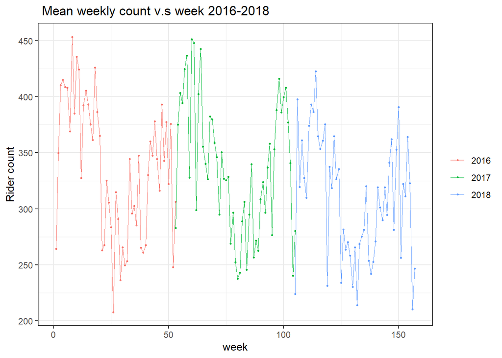

```r
#number of cyclists v.s time(Date)


allbikes$week <- week(allbikes$Date)

seventeen <- (year(allbikes$Date) == 2017)
allbikes$week[seventeen] <- allbikes$week[seventeen] + 52
eightteen <- (year(allbikes$Date) == 2018)
allbikes$week[eightteen] <- allbikes$week[eightteen] + 104



time.bikes <- aggregate(rider_count ~ week + year(Date), data = allbikes, mean)
names(time.bikes) <- c("week","year", "rider_count")

time.g <- ggplot(data = time.bikes, aes(y = rider_count, x = week, colour = as.factor(year))) + geom_point(size = 0.5) + geom_line(size = 0.1) +  theme_bw() + theme(legend.title = element_blank()) + labs(title = " Mean weekly count v.s week 2016-2018", x = "week", y = "Rider count")

time.g
```

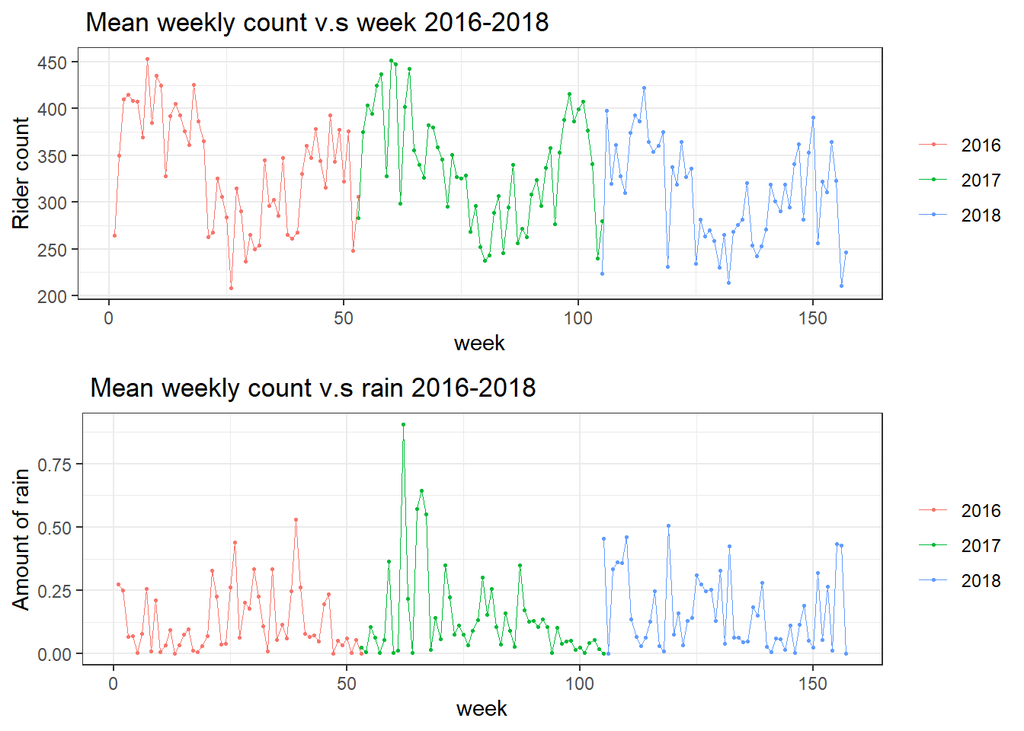

```r
#number of cyclists v.s rain

allrain$week <- week(allrain$Date)

seventeen <- (year(allrain$Date) == 2017)
allrain$week[seventeen] <- allrain$week[seventeen] + 52
eightteen <- (year(allrain$Date) == 2018)
allrain$week[eightteen] <- allrain$week[eightteen] + 104

rain.rain <- aggregate(`Amount(mm)` ~ week + year(Date), data = allrain, mean)
names(rain.rain) <- c("week","year", "amount")
rain.rain <- rain.rain[c(-160),]
rain.g <- ggplot(data = rain.rain, aes(y = amount, x = week, colour = as.factor(year))) + geom_point(size = 0.5) + geom_line(size = 0.1) +  theme_bw() + theme(legend.title = element_blank()) + labs(title = " Mean weekly count v.s rain 2016-2018", x = "week", y = "Amount of rain")


grid.arrange(time.g, rain.g)
```

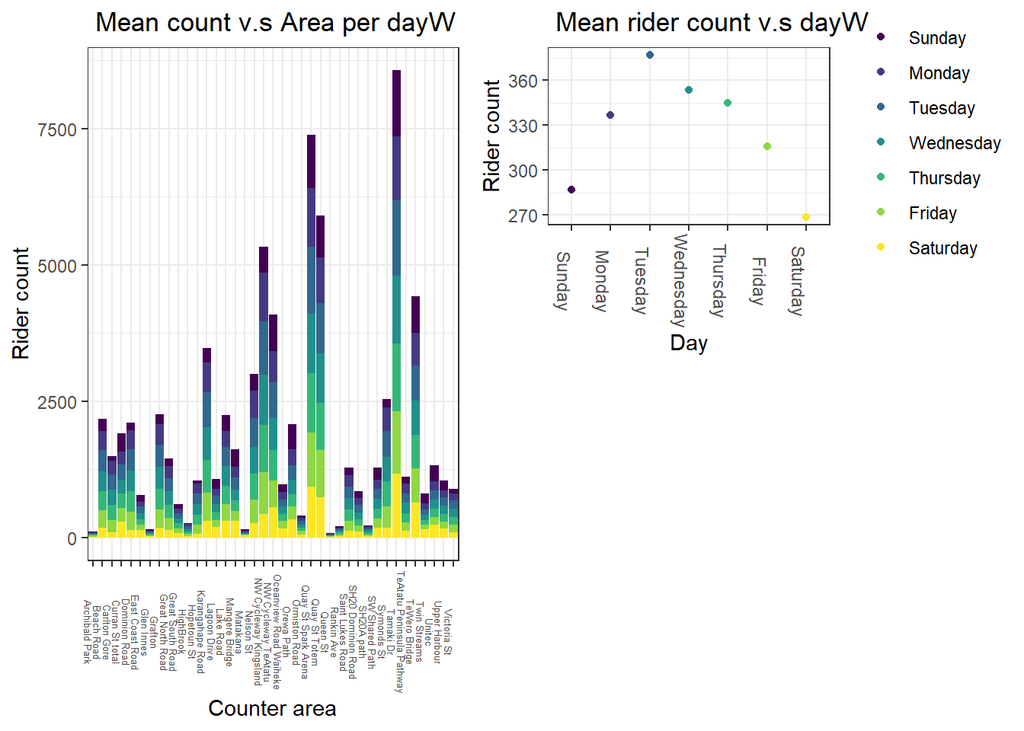

```r
#number of cyclists v.s dayW

#first lets classify each date to its corresponding day
allbikes$DayW <- wday(allbikes$Date, label = TRUE, abbr = FALSE)
day.bikes <- aggregate(rider_count ~ counter_edited + DayW, data = allbikes, mean)

day.g <- ggplot(data = day.bikes) +
geom_bar(mapping = aes(y = rider_count, x = counter_edited, fill = as.factor(DayW)) , stat = "identity") + theme_bw() + theme(axis.text.x=element_text(angle=-90,size = 5),legend.position = "none") + labs(title = " Mean count v.s Area per dayW", x = "Counter area", y = "Rider count")


day.bikes2 <- aggregate(rider_count ~ DayW, data = allbikes, mean)
day.g2 <- ggplot(data = day.bikes2) +
geom_point(mapping = aes(y = rider_count, x = as.factor(DayW), color = as.factor(DayW))) + theme_bw() + theme(axis.text.x=element_text(angle=-90),legend.title = element_blank()) + labs(title = " Mean rider count v.s dayW", x = "Day", y = "Rider count")


grid.arrange(day.g, day.g2, ncol = 4 , nrow = 3, widths = c(10, 7, 10,10),
             layout_matrix = rbind(c(1, 1, 2,2),
                                   c(1, 1,NA, NA)))
```

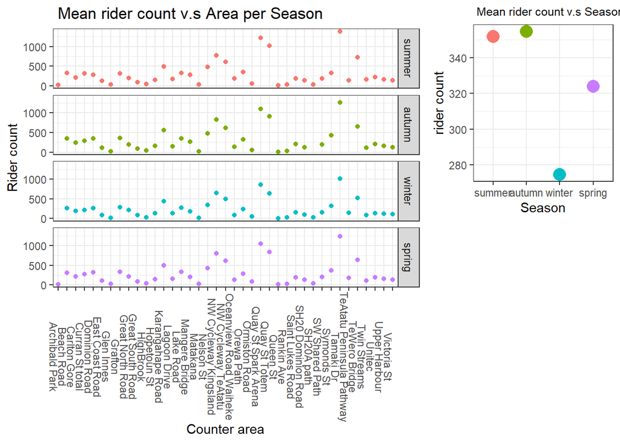

```r
#number of cyclists v.s season

#first lets classify each month to its corresponding season
temp.date <- as.Date(cut(as.Date(allbikes$Date, "%Y/%m/%d"), "month")) + 32
allbikes$Season <- factor(quarters(temp.date), levels = c("Q1", "Q2", "Q3", "Q4"),
   labels = c("summer" , "autumn", "winter", "spring" ))
season.bikes <- aggregate(rider_count ~ counter_edited + Season, data = allbikes, mean)


season.g <- ggplot(data = season.bikes, aes(y = rider_count, x= counter_edited, color = as.factor(Season))) + geom_point( ) + facet_grid(rows = as.factor(season.bikes$Season))  + theme_bw() + theme(axis.text.x=element_text(angle=-90), legend.position = "none") + labs(title = " Mean rider count v.s Area per Season", x = "Counter area", y = "Rider count")


season.bikes2 <- aggregate(rider_count ~ Season, data = allbikes, mean)
season.g2 <- ggplot(data = season.bikes2, aes(x = as.factor(Season), y = rider_count, color = as.factor(Season))) + geom_point(aes(size = 1))+ theme_bw() + labs(title = " Mean rider count v.s Season", x = "Season", y = "rider count") + theme(legend.position = "none", plot.title = element_text(size = 9.5))



grid.arrange(season.g, season.g2, ncol = 3 , nrow = 3, widths = c(10, 12, 10),
             layout_matrix = rbind(c(1, 1, 2),
                                   c(1, 1,NA)))
```

Fit a regression model to predict the number of cyclists from year, season, day of the week, and rain.

```r
#year, season and day are all accounted from the past analysis
#rain is harder to account for rain, due to the fact that location of the rain is recorded in lat,long format and it would
#require to much work to match it to location in the bikes data set. to solve this I will aggregate the bikes data set along date and do the same with the rain data set and match it with aggregated bikes data set.

model.data.bikes <- aggregate(rider_count ~ as.Date(Date) + DayW + Season, data = allbikes, sum)
names(model.data.bikes) <- c("Date", "DayW", "Season", "RiderSum")

model.data.rain <- aggregate(allrain$`Amount(mm)`~ allrain$Date  , data = allrain, sum)
model.data.rain <- model.data.rain[-c(1097),]
names(model.data.rain) <- c("Date", "Amount")

model.data <- join(model.data.bikes, model.data.rain, by = NULL, type = "left", match = "all")
model.data$Year <- year(model.data$Date)
#NOTE: the rider count will be the sum daily count for auckland

model <- lm(RiderSum ~ as.factor(Year) + as.factor(Season) + as.factor(DayW) + Amount, data = model.data)

summary(model)
```

```
##
## Call:
## lm(formula = RiderSum ~ as.factor(Year) + as.factor(Season) +
##     as.factor(DayW) + Amount, data = model.data)
##
## Residuals:
##      Min       1Q   Median       3Q      Max
## -11364.0  -1232.1    193.8   1361.3   9588.5
##
## Coefficients:
##                          Estimate Std. Error t value Pr(>|t|)
## (Intercept)             11421.039    163.393  69.899  < 2e-16 ***
## as.factor(Year)2017      1719.841    161.238  10.666  < 2e-16 ***
## as.factor(Year)2018      3077.388    161.369  19.071  < 2e-16 ***
## as.factor(Season)autumn  -259.183    186.506  -1.390 0.164913
## as.factor(Season)winter -2620.522    186.499 -14.051  < 2e-16 ***
## as.factor(Season)spring  -659.099    186.958  -3.525 0.000441 ***
## as.factor(DayW).L        -790.120    173.965  -4.542  6.2e-06 ***
## as.factor(DayW).Q       -3097.141    174.174 -17.782  < 2e-16 ***
## as.factor(DayW).C         385.145    174.140   2.212 0.027196 *
## as.factor(DayW)^4          77.142    174.293   0.443 0.658143
## as.factor(DayW)^5        -274.968    174.274  -1.578 0.114906
## as.factor(DayW)^6         368.020    174.454   2.110 0.035125 *
## Amount                   -115.053      4.242 -27.123  < 2e-16 ***
## ---
## Signif. codes:  0 '***' 0.001 '**' 0.01 '*' 0.05 '.' 0.1 ' ' 1
##
## Residual standard error: 2179 on 1083 degrees of freedom
## Multiple R-squared:  0.6078, Adjusted R-squared:  0.6035
## F-statistic: 139.9 on 12 and 1083 DF,  p-value: < 2.2e-16
```

```r
confint(model)
```

```
##                               2.5 %     97.5 %
## (Intercept)             11100.43713 11741.6417
## as.factor(Year)2017      1403.46709  2036.2157
## as.factor(Year)2018      2760.75713  3394.0184
## as.factor(Season)autumn  -625.13599   106.7709
## as.factor(Season)winter -2986.46187 -2254.5829
## as.factor(Season)spring -1025.94026  -292.2568
## as.factor(DayW).L       -1131.46644  -448.7737
## as.factor(DayW).Q       -3438.89712 -2755.3844
## as.factor(DayW).C          43.45517   726.8355
## as.factor(DayW)^4        -264.84823   419.1325
## as.factor(DayW)^5        -616.92196    66.9853
## as.factor(DayW)^6          25.71472   710.3259
## Amount                   -123.37591  -106.7294
```

```r
#example: year: 2017, DayW: Friday, Season: Winter, Amount: 10

predCount.df <- data.frame(Year = c(2017), DayW = c("Friday"), Season = c("winter"), Amount = c(10))
predict(model,predCount.df,interval = "prediction")
```

```
##       fit      lwr      upr
## 1 8917.81 4618.604 13217.02
```

From the graph we can clearly see an increase in the amount rain decreases the number of people cycling in Auckland. This is most evident in 2016, wherein the weekly amount of rain is relativity low and the number of cyclists is relativity high at the start of the year, as we move to the mid-year the amount of weekly rain greatly increases and to reflect that the number cyclists decreases greatly, and towards the end of the year the amount of rain starts to decrease and number of cyclists increases again to repeat the same cycle next year.

This behavior is confirmed by the fitted model, we see the amount of daily rain in Auckland has a p-value of 2*e^-16 i.e. it is very statistically significant, thus we can say that the for each 1 mm increase in the amount of rain the mean number of daily cyclists in Auckland decreases by between 107 and 123.